# miRNA Lasso Model

José Javier Herranz Bañón

2023-07-08

# 1 Preparación de los BL.HCandPD:

## 1.1 Librerías:

```r
library(caret)
library(glmnet)
library(tidyverse)
library(ggplot2)
```

## 1.2 Establecimiento de la semilla de aleatoriedad:

```r
set.seed(124)
```

## 1.3 Carga de la matriz de expresión:

```r
matriz_cuantitativa <- read.csv("./miRNA/std_quantification_rpmmm_norm_mirna.final_ids.csv", sep = "\t")
dim(matriz_cuantitativa)
```

```
## [1] 2656 4443
```

## 1.4 Comprobación de tipo de variables (numérica):

```r
# str(matriz_cuantitativa$PPMI.IR1.85236.V02.407051.5628.SL.4745)

length(which(lapply(matriz_cuantitativa, is.numeric) == TRUE))
```

```
## [1] 4442
```

4442 de las 4443 variables son numéricas y la que queda es string.

## 1.5 Comprobamos si hay valores nulos o ausentes:

```r
print("Nulos/Ausentes en matriz")
```

```
## [1] "Nulos/Ausentes en matriz"
```

```r
sum(is.null(matriz_cuantitativa))
```

```
## [1] 0
```

```r
sum(is.na(matriz_cuantitativa))
```

```
## [1] 0
```

## 1.6 Se le da formato al dataframe de manera que las observaciones estén en las filas y las variables en las columnas.

```r
matriz_cuantitativa_t <- as.data.frame(t(matriz_cuantitativa)) # CONVERTIMOS A LA TRANSPUESTA Y A DATAFRAME.
head(matriz_cuantitativa_t[1,c(1,2,3,4,5)], n=5)
```

```
##                    V1            V2            V3            V4            V5
## miRNA hsa-let-7a-2-3p hsa-let-7a-3p hsa-let-7a-5p hsa-let-7b-3p hsa-let-7b-5p
```

```r
colnames(matriz_cuantitativa_t) <- matriz_cuantitativa_t[1,] #ESTABLECEMOS LOS NOMBRES DE LA VARIABLES CON LA FILA DE LOS NOMBRES DE LOS miRNA.

dim(matriz_cuantitativa_t)
```

```
## [1] 4443 2656
```

```r
matriz_cuantitativa_t <- matriz_cuantitativa_t[-1,] # ELIMINAMOS LA FILA CON LOS NOMBRES DE LAS VARIABLES PORQUE YA NO HACE FALTA.
dim(matriz_cuantitativa_t)
```

```
## [1] 4442 2656
```

```r
# las variables se han pasado a strings así que las volvemos a pasar a numérico.
matriz_cuantitativa_t <- mutate_if(matriz_cuantitativa_t, is.character, as.numeric)
dim(matriz_cuantitativa_t)
```

```
## [1] 4442 2656
```

```r
saveRDS(matriz_cuantitativa_t, file = "MCpreNZVyFC")
```

## 1.7 Eliminamos variables con varianza cercana a cero.

```r
matriz_cuantitativa_t <- readRDS("./MCpreNZVyFC")
nzvariables <- nzv(matriz_cuantitativa_t) # VARIABLES CERCANAS A 0.
length(nzvariables) # NÚMERO DE VARIABLES CERCANAS A 0.
```

```
## [1] 1158
```

```r
matriz_cuantitativa_t <- matriz_cuantitativa_t[,-nzvariables] # ELIMINAMOS LAS VARIABLES CERCANAS A 0.
dim(matriz_cuantitativa_t)
```

```
## [1] 4442 1498
```

## 1.8 Eliminamos variables altamente correlacionadas.

```r
corr_me <- findCorrelation(matriz_cuantitativa_t, cutoff = 0.9) # ENCONTRAMOS LAS VARIABLES ALTAMENTE CORRELACIONADAS.

length(corr_me)
```

```
## [1] 907
```

```r
dim(matriz_cuantitativa_t)
```

```
## [1] 4442 1498
```

```r
matriz_cuantitativa_t <- matriz_cuantitativa_t[,-corr_me] # ELIMINAMOS LAS VARIABLES ALTAMENTE CORRELACIONADAS.

dim(matriz_cuantitativa_t)
```

```
## [1] 4442  591
```

```r
saveRDS(matriz_cuantitativa_t, file = "matriz_cuant_t")
```

## 1.9 Carga de la matriz reducida:

```r
matriz_cuantitativa_t <- readRDS("./matriz_cuant_t")
dim(matriz_cuantitativa_t)
```

```
## [1] 4442  591
```

## 1.10 Carga del fichero de BL.HCandPD generales:

```r
allpheno <- read.csv("./CircRNAs_PPMI_Shared/PPMI_All_Phenotype_June2022.csv")
dim(allpheno)
```

```
## [1] 3586   29
```

## 1.11 Selección de entradas de controles sanos y pacientes enfermos de primera visita.

### 1.11.1 Pacientes BL que sean enfermos o controles sanos:

```r
pacientesBL <- allpheno[ allpheno$EVENT_ID == "BL" & (allpheno$Status.1 == "PD" | allpheno$Status.1 == "HC"),] # Seleccionamos los pacientes del fichero general que que sean enfermos o controles en su primera visita
dim(pacientesBL)
```

```
## [1] 676  29
```

```r
print(paste("Parkinson Disease: ",length(as.list(pacientesBL[pacientesBL$Status.1 == "PD",1])))) # Cuantos pacientes enfermos de Parkinson
```

```
## [1] "Parkinson Disease:  532"
```

```r
print(paste("Controles sanos", length(as.list(pacientesBL[pacientesBL$Status.1 == "HC",1])))) # Cuantos controles sanos.
```

```
## [1] "Controles sanos 144"
```

### 1.11.2 Controles sanos en la matriz de expresión de miRNA:

Obtenemos todas las entradas de la matriz de expresión que sean de primera visita y de los participantes del fichero general.

```r
List.PATNO <- list()
for (i in pacientesBL$PATNO){
  List.PATNO <- append(List.PATNO, paste(i, "BL", sep = "." ), length(List.PATNO))
} # Creamos una lista copn los identificadores de los pacientes sacados del fichero general unidos a .BL para tener una lista de referencia con la que buscar patrones en los identificadores de la matriz de expresión


row.indices.PATNO.BL <- grepl(paste(List.PATNO, collapse = "|"), row.names(matriz_cuantitativa_t))
# Búsqueda de cualquier identificador de la lista (formato: XXXXX.BL) en los identificadores de la matriz

Expresiones.BL <- matriz_cuantitativa_t[row.indices.PATNO.BL,] # Seleccionamos aquellas filas que con coincidencia de número de paciente en el archivo general y que sea BaseLine.

dim(Expresiones.BL) # dimensiones de la nueva matriz hecha de los pacientes en conjunto y las variables seleccionadas de la matriz de expresión.
```

```
## [1] 659 591
```

### 1.11.3 Juntando información de expresión y el estatus del enfermo o control:

```r
FinalBL.HC_PD <- Expresiones.BL
for (a in row.names(Expresiones.BL)){
  for (c in pacientesBL$PATNO) {
    if (grepl(paste(c, "BL", sep = "." ), a) == TRUE){
      FinalBL.HC_PD[a, "Status.1"] <- pacientesBL[pacientesBL$PATNO == c, "Status.1"]
      }
    }
  }

# Comprobando visualmente:
FinalBL.HC_PD["PPMI.IR1.42014.BL.3354349.5628.SL.4775", "Status.1"]
```

```
## [1] "PD"
```

```r
pacientesBL[pacientesBL$PATNO == "42014", "Status.1"]
```

```
## [1] "PD"
```

```r
dim(FinalBL.HC_PD) # comprobamos que ha aumentado en una dimensión respecto al bloque anterior
```

```
## [1] 659 592
```

```r
saveRDS(FinalBL.HC_PD, file = "BL.HCandPD")
```

# 2 Lasso:

## 2.1 Carga de BL.HCandPD:

Cargamos los BL.HCandPD procesados en etapas anteriores, son las entradas de primeras visitas de aquellos pacientes de muestrasCA_CO_LAST.csv. Contiene ambos sets de variables de los dos archivos.

```r
BL.HCandPD <- readRDS("./BL.HCandPD")
dim(BL.HCandPD) # Se le han añadido las 29 variables del fichero general.
```

```
## [1] 659 592
```

```r
print(paste("Enfermos de Parkinson:", length(as.list(BL.HCandPD[BL.HCandPD$Status.1 == "PD",1]))))
```

```
## [1] "Enfermos de Parkinson: 515"
```

```r
print(paste("Controles sanos:", length(as.list(BL.HCandPD[BL.HCandPD$Status.1 == "HC",1]))))
```

```
## [1] "Controles sanos: 144"
```

```r
# NOTA: En la selección de pacientes en la matriz se han perdido 17 enfermos que si estaban en el archivo general.
```

## 2.2 Variables:

```r
BL.HCandPD$PD <- as.factor(ifelse(BL.HCandPD$Status.1 == "PD", 1, 0)) # Añadimos la variable respuesta a partir del estado del paciente.
z <- length(which(BL.HCandPD$PD == 0))
g <- length(which(BL.HCandPD$PD == 1))
print(paste("Cantidad de controles sanos: ", z))
```

```
## [1] "Cantidad de controles sanos:  144"
```

```r
print(paste("Cantidad de enfermos: ", g))
```

```
## [1] "Cantidad de enfermos:  515"
```

```r
Variables.miRNA <- BL.HCandPD[, !(names(BL.HCandPD) %in% c("Status.1"))] # Eliminamos las variables generales para hacer un nuevo set de BL.HCandPD con la variable respuesta y las ambundancias de miRNA (sin Status.1).


matriz.modelo <- model.matrix(PD ~ ., Variables.miRNA)[, -1] # x, eliminando el intercepto de la matriz. Se forma la matriz del modelo

Variable.respuesta <- as.data.frame(BL.HCandPD$PD, row.names = row.names(BL.HCandPD)) # y, Variable respuesta
names(Variable.respuesta)[names(Variable.respuesta) == "BL.HCandPD$PD"] <- "PD"
# BL.HCandPD[,c("PD", "Status.1")] # Comprobar que los HC sean 0 y los PD 1.
length(Variable.respuesta$PD)
```

```
## [1] 659
```

## 2.3 Partición de entrenamiento y test:

```r
train <- sample(1:nrow(Variable.respuesta), nrow(Variable.respuesta) * 0.7) # Genera el índice para las particiones. Índice de entrenamiento.
test <- (-train) # Índice de test.
matriz.modelo.test <- matriz.modelo[test,] # Partición para entrenamiento de x
respuesta.test <- Variable.respuesta[test,] # Partición para entrenamiento de y.
```

## 2.4 Comprobación de proporción de la muestra:

```r
length.train.v.p <- length(Variable.respuesta[train,])
length.test.v.p <-length(respuesta.test)

print(paste("Cantidad de filas de entrenamiento: ", length.train.v.p))
```

```
## [1] "Cantidad de filas de entrenamiento:  461"
```

```r
print(paste("Cantidad de filas de test: ", length.test.v.p))
```

```
## [1] "Cantidad de filas de test:  198"
```

```r
print(paste("Cantidad de filas totales: ", (length.train.v.p+length.test.v.p)))
```

```
## [1] "Cantidad de filas totales:  659"
```

```r
print(paste("Enfermos totales: ", length(Variable.respuesta[Variable.respuesta$PD == "1",])))
```

```
## [1] "Enfermos totales:  515"
```

```r
print(paste("Controles sanos totales: ", length(Variable.respuesta[Variable.respuesta$PD == "0",])))
```

```
## [1] "Controles sanos totales:  144"
```

```r
VR.train <- Variable.respuesta[train,]

print(paste("Controles sanos en test: ", length(respuesta.test[respuesta.test == "0"])))
```

```
## [1] "Controles sanos en test:  39"
```

```r
print(paste("Controles sanos en entrenamiento: ", length(VR.train[VR.train == "0"])))
```

```
## [1] "Controles sanos en entrenamiento:  105"
```

```r
print(paste("Enfermos en test: ", length(respuesta.test[respuesta.test == "1"])))
```

```
## [1] "Enfermos en test:  159"
```

```r
print(paste("Enfermos en entrenamiento: ", length(VR.train[VR.train == "1"])))
```

```
## [1] "Enfermos en entrenamiento:  356"
```

Conclusión: Los conjuntos de entrenamiento y de test tienen clases desbalanceadas (Proporción enfermos/sanos del 400% para test y del 339% para entrenamiento).

## 2.5 El modelo:

```r
cv.lasso.model <- cv.glmnet(matriz.modelo[train, ], Variable.respuesta[train, ], alpha=1, nfolds=10, family=binomial) # Modelo lasso, con validación cruzada de 10 pliegues. Distribución binomial (hará regresión logística)
saveRDS(cv.lasso.model, file = "cv.lasso.model")
```

## 2.6 Elección de lambda:

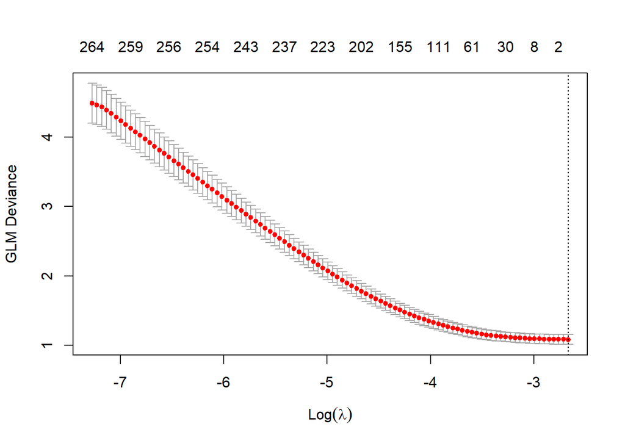

```r
cv.lasso.model <- readRDS("./cv.lasso.model")
plot(cv.lasso.model)
```

```r
mejor.lambda <- cv.lasso.model$lambda.min # Lambda con el error mas bajo.
mejor.lambda
```

```
## [1] 0.06937514
```

## 2.7 Predicción:

```r
miRNA.pred <- predict(cv.lasso.model, s = mejor.lambda, newx = matriz.modelo.test, type="response") # Predicción con los BL.HCandPD de test.
saveRDS(miRNA.pred, file = "miRNA.pred")
```

## 2.8 Paso de probabilidad a valores de respuesta:

```r
miRNA.pred <- readRDS("./miRNA.pred")
#prob.miRNA <- exp(miRNA.pred)/(1+exp(miRNA.pred)) # Conversión de logits a probabilidades.
Prediction <- factor(ifelse(miRNA.pred > 0.5, 1, 0)) # Se asume que probabilidades por encima del 50% son 1 y por debajo o iguales 0. PREGUNTAR
length(Prediction)
```

```
## [1] 198
```

```r
# Prediction
```

## 2.9 Matriz de confusión:

Para comprobar la efectividad del modelo usamos una matriz de confusión y atendemos a Accuracy, P-Value [Acc > NIR] y Mcnemar’s Test P-Value.

```r
CML<- readRDS("./CML")
CML
```

```
## Confusion Matrix and Statistics
##
##           Reference
## Prediction   0   1
##          0   0   0
##          1  39 159
##
##                Accuracy : 0.803
##                  95% CI : (0.7407, 0.856)
##     No Information Rate : 0.803
##     P-Value [Acc > NIR] : 0.5427
##
##                   Kappa : 0
##
##  Mcnemar's Test P-Value : 1.166e-09
##
##             Sensitivity : 1.000
##             Specificity : 0.000
##          Pos Pred Value : 0.803
##          Neg Pred Value :   NaN
##              Prevalence : 0.803
##          Detection Rate : 0.803
##    Detection Prevalence : 1.000
##       Balanced Accuracy : 0.500
##
##        'Positive' Class : 1
##
```

P-Value [Acc > NIR] : No significativo. Nos dice que no rechazamos la hipótesis nula de que Accuracy es igual o menor que el NIR. Mcnemar’s Test P-Value : Significativo. Rechazamos la hipótesis nula de que la diferencia en resultados se deban al azar, es decir no hay homogeneidad marginal.

## 2.10 Variables elegidas por el modelo:

```r
coef.pred <- predict(cv.lasso.model, s = mejor.lambda, type= "coefficients" )
# coef.pred@i contiene el índice de que variables se han usado y coef.pred@Dimnames[[1]] contiene los nombres de todas las variables

variables <- coef.pred@Dimnames[[1]][(coef.pred@i+1)] # +1 es porque las dos listas tienen índices distintos, uno empieza en 0 y el otro en 1. Siendo el 1 de coef.pred@Dimnames el intercepto, mientras que en el otro es el 0.

saveRDS(variables, file = "variables.finales")
```

```r
variables <- readRDS("./variables.finales")
variables
```

```
## [1] "(Intercept)"
```

# 3 Lasso con submuestreo:

## 3.1 Submuestreo sobre los enfermos

```r
dim(Variables.miRNA)
```

```
## [1] 659 592
```

```r
print(paste("Enfermos de Parkinson:", length(as.list(Variables.miRNA[Variables.miRNA$PD == "1",1]))))
```

```
## [1] "Enfermos de Parkinson: 515"
```

```r
print(paste("Controles sanos:", length(as.list(Variables.miRNA[Variables.miRNA$PD == "0",1]))))
```

```
## [1] "Controles sanos: 144"
```

```r
print(paste("Participantes totales:", length(as.list(Variables.miRNA[,1]))))
```

```
## [1] "Participantes totales: 659"
```

```r
submuestreo.negativo <- sample(row.names(Variables.miRNA[Variables.miRNA$PD == "1",]), 371) # Usaremos los nombres de 371 filas para excluirlas.

BL.HCandPD.sub <- Variables.miRNA[!(row.names(Variables.miRNA) %in% submuestreo.negativo),] # Excluimos aquellas filas de enfermos seleccionadas anteriormente, dejando 144.
print(paste("Enfermos tras balanceo:", length(as.list(BL.HCandPD.sub[BL.HCandPD.sub$PD == "1",1]))))
```

```
## [1] "Enfermos tras balanceo: 144"
```

```r
saveRDS(BL.HCandPD.sub, file = "BL.HCandPD.sub")
```

```r
BL.HCandPD.sub <- readRDS("./BL.HCandPD.sub")
print(paste("Enfermos en los BL.HCandPD equilibrados:" ,length(which(BL.HCandPD.sub$PD == "1"))))
```

```
## [1] "Enfermos en los BL.HCandPD equilibrados: 144"
```

```r
print(paste("Controles sanos en los BL.HCandPD equilibrados:" ,length(which(BL.HCandPD.sub$PD == "0"))))
```

```
## [1] "Controles sanos en los BL.HCandPD equilibrados: 144"
```

## 3.2 Partición de entrenamiento y test:

```r
train <- sample(1:nrow(BL.HCandPD.sub), nrow(BL.HCandPD.sub) * 0.7) # Genera el índice para las particiones. Índice de entrenamiento.

# Creando la matriz del modelo.
matriz.modelo.sub <- model.matrix(PD ~ ., BL.HCandPD.sub)[, -1] # x, eliminando el intercepto de la matriz.

# Creando la variable respuesta.
Variable.respuesta.sub <- as.data.frame(BL.HCandPD.sub$PD, row.names = row.names(BL.HCandPD.sub)) # y

names(Variable.respuesta)[names(Variable.respuesta) == "BL.HCandPD$PD"] <- "PD"

test <- (-train) # Índice de test.
matriz.modelo.test.sub <- matriz.modelo.sub[test,] # Partición para entrenamiento de x
respuesta.test.sub <- Variable.respuesta.sub[test,] # Partición para entrenamiento de y.
```

## 3.3 Comprobación de equilibrado de las particiones:

```r
VR.train.sub <- Variable.respuesta.sub[train,]

print(paste("Controles sanos en test: ", length(respuesta.test.sub[respuesta.test.sub == "0"])))
```

```
## [1] "Controles sanos en test:  40"
```

```r
print(paste("Controles sanos en entrenamiento: ", length(VR.train.sub[VR.train.sub == "0"])))
```

```
## [1] "Controles sanos en entrenamiento:  104"
```

```r
print(paste("Enfermos en test: ", length(respuesta.test.sub[respuesta.test.sub == "1"])))
```

```
## [1] "Enfermos en test:  47"
```

```r
print(paste("Enfermos en entrenamiento: ", length(VR.train.sub[VR.train.sub == "1"])))
```

```
## [1] "Enfermos en entrenamiento:  97"
```

## 3.4 El modelo:

```r
cv.lasso.model.sub <- cv.glmnet(matriz.modelo.sub[train, ], Variable.respuesta.sub[train, ], alpha=1, nfolds=10, family=binomial) # Modelo lasso, con validación cruzada de 10 pliegues. Distribución binomial (hará regresión logística)
saveRDS(cv.lasso.model.sub, file = "cv.lasso.model.sub")
```

## 3.5 Elección de lambda:

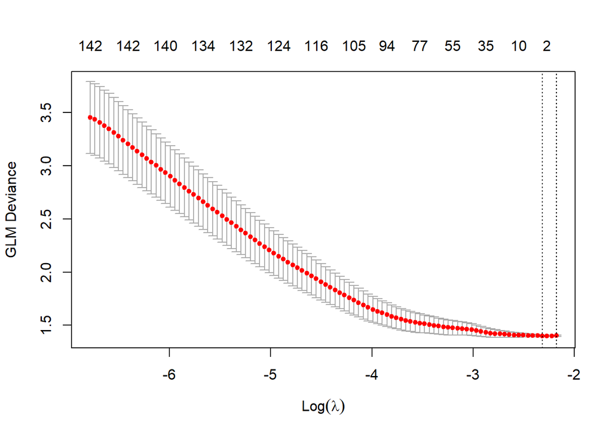

```r
cv.lasso.model.sub <- readRDS("./cv.lasso.model.sub")
plot(cv.lasso.model.sub)
```

```r
mejor.lambda.sub <- cv.lasso.model.sub$lambda.min # Lambda con el error mas bajo-
mejor.lambda.sub
```

```
## [1] 0.09854044
```

## 3.6 Predicción:

```r
miRNA.pred.sub <- predict(cv.lasso.model.sub, s = mejor.lambda.sub, newx = matriz.modelo.test.sub, type="response") # Predicción con los BL.HCandPD de test.
saveRDS(miRNA.pred.sub, file = "miRNA.pred.sub")
```

## 3.7 Paso de probabilidad a valores de respuesta:

```r
miRNA.pred.sub <- readRDS("./miRNA.pred.sub")

Prediction.sub <- factor(ifelse(miRNA.pred.sub > 0.5, 1, 0)) # Se asume que probabilidades por encima del 50% son 1 y por debajo o iguales 0. PREGUNTAR
length(Prediction.sub)
```

```
## [1] 87
```

## 3.8 Matriz de confusión:

```r
CML.sub <- confusionMatrix( Prediction.sub, respuesta.test.sub, positive = "1")
saveRDS(CML.sub, file ="CML.sub")
```

```r
CML.sub <- readRDS("./CML.sub")
CML.sub
```

```
## Confusion Matrix and Statistics
##
##           Reference
## Prediction  0  1
##          0  4  2
##          1 36 45
##
##                Accuracy : 0.5632
##                  95% CI : (0.4526, 0.6694)
##     No Information Rate : 0.5402
##     P-Value [Acc > NIR] : 0.3746
##
##                   Kappa : 0.0613
##
##  Mcnemar's Test P-Value : 8.636e-08
##
##             Sensitivity : 0.9574
##             Specificity : 0.1000
##          Pos Pred Value : 0.5556
##          Neg Pred Value : 0.6667
##              Prevalence : 0.5402
##          Detection Rate : 0.5172
##    Detection Prevalence : 0.9310
##       Balanced Accuracy : 0.5287
##
##        'Positive' Class : 1
##
```

## 3.9 Variables elegidas por el modelo:

```r
coef.pred.sub <- predict(cv.lasso.model.sub, s = mejor.lambda, type= "coefficients" )
variables.sub <- coef.pred.sub@Dimnames[[1]][(coef.pred@i+1)] # +1 es porque las dos listas tienen índices distintos, uno empieza en 0 y el otro en 1.
saveRDS(variables.sub, file = "variables.finales.sub")
```

```r
variables.sub <- readRDS("./variables.finales.sub")
variables.sub
```

```
## [1] "(Intercept)"
```

# 4 Comparación de modelos:

```r
par(c(2,1))
```

```r
CML <- readRDS("./CML")
CML.sub <- readRDS("./CML.sub")
CML
```

```
## Confusion Matrix and Statistics
##
##           Reference
## Prediction   0   1
##          0   0   0
##          1  39 159
##
##                Accuracy : 0.803
##                  95% CI : (0.7407, 0.856)
##     No Information Rate : 0.803
##     P-Value [Acc > NIR] : 0.5427
##
##                   Kappa : 0
##
##  Mcnemar's Test P-Value : 1.166e-09
##
##             Sensitivity : 1.000
##             Specificity : 0.000
##          Pos Pred Value : 0.803
##          Neg Pred Value :   NaN
##              Prevalence : 0.803
##          Detection Rate : 0.803
##    Detection Prevalence : 1.000
##       Balanced Accuracy : 0.500
##
##        'Positive' Class : 1
##
```

```r
CML.sub
```

```
## Confusion Matrix and Statistics
##
##           Reference
## Prediction  0  1
##          0  4  2
##          1 36 45
##
##                Accuracy : 0.5632
##                  95% CI : (0.4526, 0.6694)
##     No Information Rate : 0.5402
##     P-Value [Acc > NIR] : 0.3746
##
##                   Kappa : 0.0613
##
##  Mcnemar's Test P-Value : 8.636e-08
##
##             Sensitivity : 0.9574
##             Specificity : 0.1000
##          Pos Pred Value : 0.5556
##          Neg Pred Value : 0.6667
##              Prevalence : 0.5402
##          Detection Rate : 0.5172
##    Detection Prevalence : 0.9310
##       Balanced Accuracy : 0.5287
##
##        'Positive' Class : 1
##
```

Las variables conservadas en los dos modelos han sido los interceptos nada más.

# 5 Análisis por PCA:

## 5.1 Proporción original:

### 5.1.1 PCA:

```r
pca <- prcomp(BL.HCandPD[,!names(BL.HCandPD) %in% c("PD", "Status.1")], scale = TRUE) # Usamos todas las variables numéricas pero obviamos las de respuesta.
```

#### 5.1.1.1 Varianza explicada por cada componente principal:

```r
VE <- pca$sdev^2
PVE <- VE / sum(VE)
rPVE <- round(PVE, 2)
rPVE
```

```
##   [1] 0.03 0.02 0.02 0.01 0.01 0.01 0.01 0.01 0.01 0.01 0.01 0.01 0.01 0.01 0.01
##  [16] 0.01 0.01 0.01 0.01 0.01 0.01 0.01 0.01 0.01 0.01 0.01 0.01 0.01 0.01 0.01
##  [31] 0.01 0.01 0.01 0.01 0.01 0.01 0.01 0.01 0.00 0.00 0.00 0.00 0.00 0.00 0.00
##  [46] 0.00 0.00 0.00 0.00 0.00 0.00 0.00 0.00 0.00 0.00 0.00 0.00 0.00 0.00 0.00
##  [61] 0.00 0.00 0.00 0.00 0.00 0.00 0.00 0.00 0.00 0.00 0.00 0.00 0.00 0.00 0.00
##  [76] 0.00 0.00 0.00 0.00 0.00 0.00 0.00 0.00 0.00 0.00 0.00 0.00 0.00 0.00 0.00
##  [91] 0.00 0.00 0.00 0.00 0.00 0.00 0.00 0.00 0.00 0.00 0.00 0.00 0.00 0.00 0.00
## [106] 0.00 0.00 0.00 0.00 0.00 0.00 0.00 0.00 0.00 0.00 0.00 0.00 0.00 0.00 0.00
## [121] 0.00 0.00 0.00 0.00 0.00 0.00 0.00 0.00 0.00 0.00 0.00 0.00 0.00 0.00 0.00
## [136] 0.00 0.00 0.00 0.00 0.00 0.00 0.00 0.00 0.00 0.00 0.00 0.00 0.00 0.00 0.00
## [151] 0.00 0.00 0.00 0.00 0.00 0.00 0.00 0.00 0.00 0.00 0.00 0.00 0.00 0.00 0.00
## [166] 0.00 0.00 0.00 0.00 0.00 0.00 0.00 0.00 0.00 0.00 0.00 0.00 0.00 0.00 0.00
## [181] 0.00 0.00 0.00 0.00 0.00 0.00 0.00 0.00 0.00 0.00 0.00 0.00 0.00 0.00 0.00
## [196] 0.00 0.00 0.00 0.00 0.00 0.00 0.00 0.00 0.00 0.00 0.00 0.00 0.00 0.00 0.00
## [211] 0.00 0.00 0.00 0.00 0.00 0.00 0.00 0.00 0.00 0.00 0.00 0.00 0.00 0.00 0.00
```

[output cut: 25 more lines]

```r
length(which(rPVE != 0))
```

```
## [1] 38
```

#### 5.1.1.2 Loadings de las componentes principales que explican un 1% o más:

```r
pca$rotation[1:38]
```

```
##  [1]  0.0378331918  0.0070638582  0.0959511035  0.0668188936  0.1367325312
##  [6]  0.0006516184  0.0459208290 -0.0025652812  0.0323411385  0.0470952271
## [11]  0.0215755445  0.0297288979 -0.0111983574 -0.0008179765  0.0412871148
## [16]  0.0230947860 -0.0002333419  0.0191834966  0.0013892226  0.0420450670
## [21]  0.0184305017  0.0244912496  0.0055676923  0.0125337909  0.0461659417
## [26]  0.0214662191  0.0058909543 -0.0011654023 -0.0146840382  0.0083883143
## [31]  0.0266730619  0.0461055008  0.0020395715  0.0604847493 -0.0128965138
## [36]  0.0314741185 -0.0002211078  0.0285875164
```

### 5.1.2 Representación:

```r
pca.df <- as.data.frame(pca$x, stringsAsFactors = F)
pca.df <- cbind(Estatus = BL.HCandPD$PD, pca.df)
```

#### 5.1.2.1 PCA:

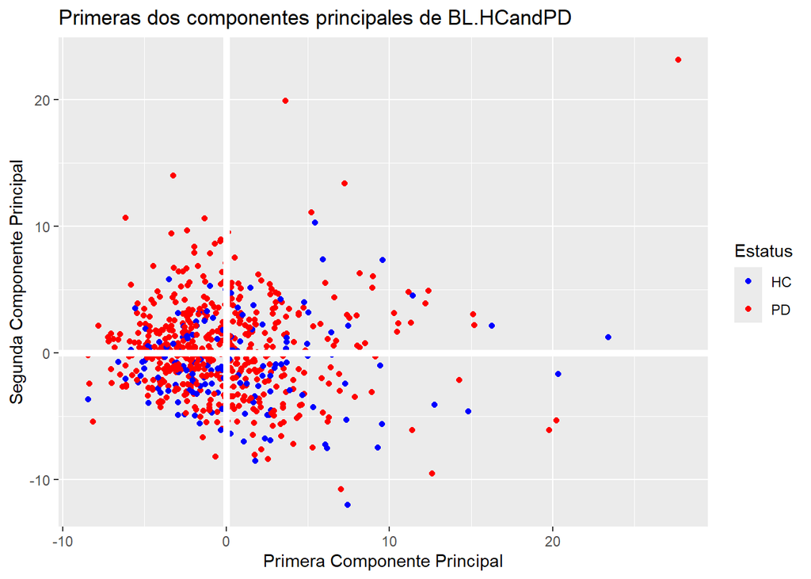

```r
ggplot(pca.df, aes(PC1, PC2)) + geom_point(aes(color= Estatus)) + modelr::geom_ref_line(h = 0) + modelr::geom_ref_line(v = 0) + xlab("Primera Componente Principal") + ylab("Segunda Componente Principal") + ggtitle("Primeras dos componentes principales de BL.HCandPD") + scale_color_manual(values= c("blue", "red"), labels = c("HC" , "PD"))
```

```r
# Los azules corresponden con los 0, que son los controles sanos, y los rojos corresponden con los 1 que son enfermos de Parkinson.
```

## 5.2 Proporción balanceada:

### 5.2.1 PCA:

```r
pca.sub <- prcomp(BL.HCandPD.sub[,!names(BL.HCandPD.sub) %in% c("PD", "Status.1")], scale = TRUE) # Usamos todas las variables numéricas pero obviamos las de respuesta.
```

#### 5.2.1.1 Varianza explicada por cada componente principal:

```r
VE.s <- pca.sub$sdev^2
PVE.s <- VE.s / sum(VE.s)
rPVE.s <- round(PVE.s, 2)
rPVE.s
```

```
##   [1] 0.04 0.03 0.02 0.01 0.01 0.01 0.01 0.01 0.01 0.01 0.01 0.01 0.01 0.01 0.01
##  [16] 0.01 0.01 0.01 0.01 0.01 0.01 0.01 0.01 0.01 0.01 0.01 0.01 0.01 0.01 0.01
##  [31] 0.01 0.01 0.01 0.01 0.01 0.01 0.01 0.01 0.01 0.01 0.01 0.01 0.01 0.01 0.01
##  [46] 0.01 0.01 0.01 0.01 0.01 0.01 0.01 0.01 0.01 0.01 0.01 0.01 0.01 0.01 0.01
##  [61] 0.01 0.01 0.01 0.01 0.01 0.00 0.00 0.00 0.00 0.00 0.00 0.00 0.00 0.00 0.00
##  [76] 0.00 0.00 0.00 0.00 0.00 0.00 0.00 0.00 0.00 0.00 0.00 0.00 0.00 0.00 0.00
##  [91] 0.00 0.00 0.00 0.00 0.00 0.00 0.00 0.00 0.00 0.00 0.00 0.00 0.00 0.00 0.00
## [106] 0.00 0.00 0.00 0.00 0.00 0.00 0.00 0.00 0.00 0.00 0.00 0.00 0.00 0.00 0.00
## [121] 0.00 0.00 0.00 0.00 0.00 0.00 0.00 0.00 0.00 0.00 0.00 0.00 0.00 0.00 0.00
## [136] 0.00 0.00 0.00 0.00 0.00 0.00 0.00 0.00 0.00 0.00 0.00 0.00 0.00 0.00 0.00
## [151] 0.00 0.00 0.00 0.00 0.00 0.00 0.00 0.00 0.00 0.00 0.00 0.00 0.00 0.00 0.00
## [166] 0.00 0.00 0.00 0.00 0.00 0.00 0.00 0.00 0.00 0.00 0.00 0.00 0.00 0.00 0.00
## [181] 0.00 0.00 0.00 0.00 0.00 0.00 0.00 0.00 0.00 0.00 0.00 0.00 0.00 0.00 0.00
## [196] 0.00 0.00 0.00 0.00 0.00 0.00 0.00 0.00 0.00 0.00 0.00 0.00 0.00 0.00 0.00
## [211] 0.00 0.00 0.00 0.00 0.00 0.00 0.00 0.00 0.00 0.00 0.00 0.00 0.00 0.00 0.00
## [226] 0.00 0.00 0.00 0.00 0.00 0.00 0.00 0.00 0.00 0.00 0.00 0.00 0.00 0.00 0.00
## [241] 0.00 0.00 0.00 0.00 0.00 0.00 0.00 0.00 0.00 0.00 0.00 0.00 0.00 0.00 0.00
## [256] 0.00 0.00 0.00 0.00 0.00 0.00 0.00 0.00 0.00 0.00 0.00 0.00 0.00 0.00 0.00
## [271] 0.00 0.00 0.00 0.00 0.00 0.00 0.00 0.00 0.00 0.00 0.00 0.00 0.00 0.00 0.00
## [286] 0.00 0.00 0.00
```

```r
length(which(rPVE.s != 0))
```

```
## [1] 65
```

#### 5.2.1.2 Loadings de las componentes principales que explican un 1% o más:

```r
pca.sub$rotation[1:67]
```

```
##  [1]  5.494908e-02 -1.163415e-02  9.028209e-02  8.336561e-02  1.206929e-01
##  [6]  4.714488e-03  4.723913e-02  3.884472e-03  1.889309e-02  4.492724e-02
## [11]  1.727198e-02  4.095325e-02 -2.737626e-02  9.674901e-03  5.040073e-02
## [16]  9.487838e-03 -3.275297e-03  2.060829e-02 -9.597688e-05  2.948414e-02
## [21]  2.327070e-02  3.917407e-02  1.684213e-02  1.802392e-04  5.587811e-02
## [26]  3.003712e-02  3.461919e-03 -9.526620e-03 -3.795252e-03 -4.132274e-03
## [31]  4.484903e-02  7.891139e-02  2.854435e-02  7.093294e-02 -6.937073e-03
## [36]  5.365510e-02 -6.708615e-06  3.444035e-02  6.849704e-02  8.752677e-03
## [41]  1.376116e-02  6.889982e-02  3.682588e-03  5.426832e-02  4.366568e-04
## [46] -2.731216e-03 -1.031006e-02 -8.749182e-03  7.572323e-03  2.516908e-03
## [51]  8.601368e-02  8.605003e-03  3.459065e-02  4.508655e-02  3.908778e-02
## [56]  6.763152e-02  6.287248e-03  1.799373e-02  6.130985e-02  3.744742e-02
## [61]  4.042124e-02  4.004650e-02  3.218008e-02  7.004213e-02  9.561062e-02
## [66]  3.739324e-02  4.994357e-03
```

### 5.2.2 Representación:

```r
pca.sub.df <- as.data.frame(pca.sub$x, stringsAsFactors = F)
pca.sub.df <- cbind(Estatus = BL.HCandPD.sub$PD, pca.sub.df)
```

#### 5.2.2.1 PCA:

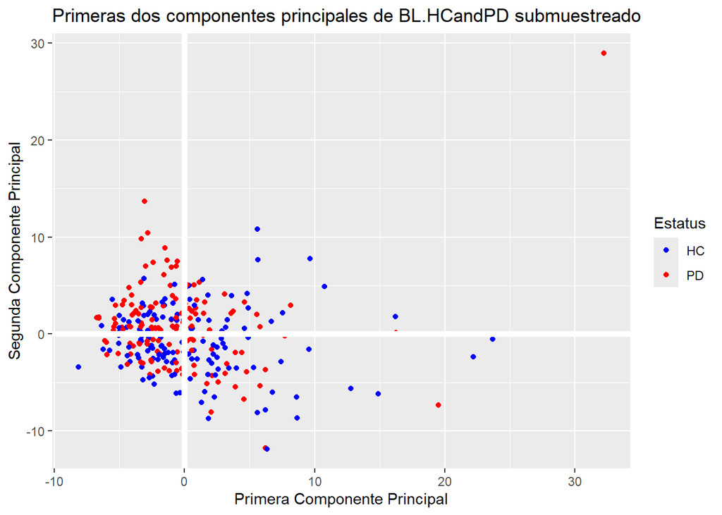

```r
ggplot(pca.sub.df, aes(PC1, PC2)) + geom_point(aes(color= Estatus)) + modelr::geom_ref_line(h = 0) + modelr::geom_ref_line(v = 0) + xlab("Primera Componente Principal") + ylab("Segunda Componente Principal") + ggtitle("Primeras dos componentes principales de BL.HCandPD submuestreado") + scale_color_manual(values= c("blue", "red"), labels = c("HC" , "PD"))
```

```r
# Los azules corresponden con los 0, que son los controles sanos, y los rojos corresponden con los 1 que son enfermos de Parkinson.
```

# 6 Lasso balanceado con la matriz completa:

## 6.1 Creando la matriz de altas dimensiones con enfermos y controles sanos:

Repetimos pasos de la sección 1.11.2. con la matriz completa, sin eliminar variables.

### 6.1.1 Carga de la matriz sin reducir:

```r
MCpreNZVyFC <- readRDS("./MCpreNZVyFC") # Carga de la matriz matriz_cuantitativa_t sin reducir sus variables
```

### 6.1.2 Seleccionando filas que se encuentren en los dos ficheros y sean de primeras visitas:

```r
full.matrix.BL <- MCpreNZVyFC[row.indices.PATNO.BL,] # Con el índice obtenido en pasos anteriores

dim(full.matrix.BL)
```

```
## [1]  659 2656
```

### 6.1.3 Añadir la variable Status.1 a la matriz cuantitativa:

```r
Final.full.matrix.BL <- full.matrix.BL
for (a in row.names(full.matrix.BL)){
  for (c in pacientesBL$PATNO) {
    if (grepl(paste(c, "BL", sep = "." ), a) == TRUE){
      Final.full.matrix.BL[a, "Status.1"] <- pacientesBL[pacientesBL$PATNO == c, "Status.1"]
      }
    }
}
saveRDS(Final.full.matrix.BL, file = "Final.full.matrix.BL")
```

```r
Final.full.matrix.BL <- readRDS("./Final.full.matrix.BL")
# Comprobando visualmente:


Final.full.matrix.BL["PPMI.IR1.42014.BL.3354349.5628.SL.4775", "Status.1"]
```

```
## [1] "PD"
```

```r
pacientesBL[pacientesBL$PATNO == "42014", "Status.1"]
```

```
## [1] "PD"
```

```r
dim(Final.full.matrix.BL)
```

```
## [1]  659 2657
```

### 6.1.4 Paso de la variable Status.1. a binaria:

```r
head(Final.full.matrix.BL[,"Status.1"])
```

```
## [1] "PD" "PD" "PD" "PD" "PD" "PD"
```

```r
length(which(Final.full.matrix.BL$Status.1 == "PD"))
```

```
## [1] 515
```

```r
Final.full.matrix.BL$Status.1 <- as.factor(ifelse(Final.full.matrix.BL$Status.1 == "PD", 1, 0))

head(Final.full.matrix.BL[,"Status.1"])
```

```
## [1] 1 1 1 1 1 1
## Levels: 0 1
```

```r
length(which(Final.full.matrix.BL$Status.1 == 1))
```

```
## [1] 515
```

```r
print(paste("Enfermos de Parkinson:", length(as.list(Final.full.matrix.BL[Final.full.matrix.BL$Status.1 == "1",1]))))
```

```
## [1] "Enfermos de Parkinson: 515"
```

```r
print(paste("Controles sanos:", length(as.list(Final.full.matrix.BL[Final.full.matrix.BL$Status.1 == "0",1]))))
```

```
## [1] "Controles sanos: 144"
```

### 6.1.5 Balanceo

```r
Final.full.matrix.BL.sub <- Final.full.matrix.BL[!(row.names(Final.full.matrix.BL) %in% submuestreo.negativo),]
saveRDS(Final.full.matrix.BL.sub, file = "Final.full.matrix.BL.sub")
```

```r
Final.full.matrix.BL.sub <- readRDS("./Final.full.matrix.BL.sub")
```

```r
print(paste("Enfermos de Parkinson tras balanceo:", length(as.list(Final.full.matrix.BL.sub[Final.full.matrix.BL.sub$Status.1 == "1",1]))))
```

```
## [1] "Enfermos de Parkinson tras balanceo: 144"
```

## 6.2 Lasso balanceado:

### 6.2.1 Variables y partición de entrenamiento y test:

```r
test.full <- sample(1:nrow(Final.full.matrix.BL.sub), nrow(Final.full.matrix.BL.sub) * 0.3)

matriz.modelo.full <- model.matrix(Status.1 ~ ., Final.full.matrix.BL.sub)[, -1]

dim(matriz.modelo.full)
```

```
## [1]  288 2656
```

```r
length(test.full)
```

```
## [1] 86
```

```r
matriz.modelo.full.test <- matriz.modelo.full[test.full,]
respuesta.full.test <- Final.full.matrix.BL.sub[test.full, "Status.1"]


saveRDS(matriz.modelo.full.test, file = "matriz.modelo.full.test")

matriz.modelo.full.train <- matriz.modelo.full[-test.full,]
respuesta.full.train <- Final.full.matrix.BL.sub[-test.full, "Status.1"]

saveRDS(respuesta.full.test, file = "respuesta.full.test.F")

dim(matriz.modelo.full.test)
```

```
## [1]   86 2656
```

```r
length(respuesta.full.test)
```

```
## [1] 86
```

```r
print(length(which(respuesta.full.test == "1")))
```

```
## [1] 50
```

```r
dim(matriz.modelo.full.train)
```

```
## [1]  202 2656
```

```r
length(respuesta.full.train)
```

```
## [1] 202
```

```r
print(length(which(respuesta.full.train == "1")))
```

```
## [1] 94
```

### 6.2.2 Entrenamiento del modelo:

```r
cv.lasso.model.full <- cv.glmnet(matriz.modelo.full.train, respuesta.full.train, alpha=1, nfolds=10, family=binomial)
saveRDS(cv.lasso.model.full, file = "cv.lasso.model.full")
```

### 6.2.3 Elección de lambda:

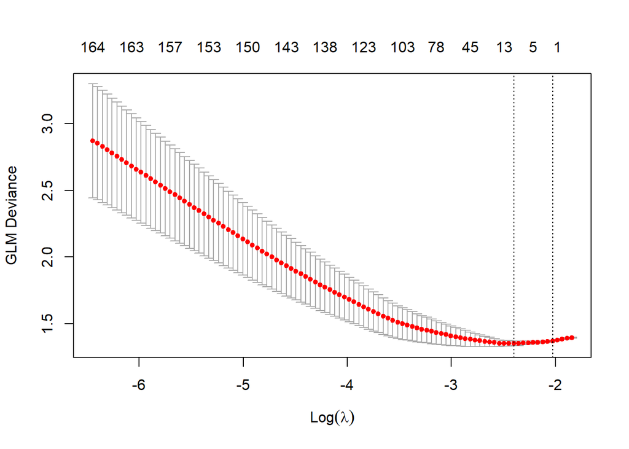

```r
cv.lasso.model.full <- readRDS("./cv.lasso.model.full")
plot(cv.lasso.model.full)
```

```r
mejor.lambda.full <- cv.lasso.model.full$lambda.min # Lambda con el error mas bajo-
mejor.lambda.full
```

```
## [1] 0.09067183
```

### 6.2.4 Predicción:

```r
matriz.modelo.full.test <- readRDS(file = "./matriz.modelo.full.test")
miRNA.pred.full <- predict(cv.lasso.model.full, s = mejor.lambda.full, newx = matriz.modelo.full.test, type="response")
saveRDS(miRNA.pred.full, "miRNA.pred.full.little.lambda")
```

### 6.2.5 Paso de probabilidad a respuesta:

```r
Prediction.full <- factor(ifelse(miRNA.pred.full > 0.5, 1, 0))
```

```r
length(Prediction.full)
```

```
## [1] 86
```

```r
print(length(which(Prediction.full == "1")))
```

```
## [1] 52
```

```r
saveRDS(Prediction.full, file = "Prediction.full")
```

## 6.3 Matriz de confusión del lasso balanceado con la matriz sin reducir:

```r
Prediction.full <- readRDS("./Prediction.full")
CML.sub.full <- confusionMatrix( Prediction.full, respuesta.full.test, positive = "1")
saveRDS(CML.sub.full, file ="CML.sub.full")
```

```r
CML.sub.full <- readRDS("./CML.sub.full")
CML.sub.full
```

```
## Confusion Matrix and Statistics
##
##           Reference
## Prediction  0  1
##          0 24 10
##          1 20 32
##
##                Accuracy : 0.6512
##                  95% CI : (0.5408, 0.7508)
##     No Information Rate : 0.5116
##     P-Value [Acc > NIR] : 0.006244
##
##                   Kappa : 0.3057
##
##  Mcnemar's Test P-Value : 0.100348
##
##             Sensitivity : 0.7619
##             Specificity : 0.5455
##          Pos Pred Value : 0.6154
##          Neg Pred Value : 0.7059
##              Prevalence : 0.4884
##          Detection Rate : 0.3721
##    Detection Prevalence : 0.6047
##       Balanced Accuracy : 0.6537
##
##        'Positive' Class : 1
##
```

## 6.4 Variables elegidas:

```r
coef.pred.full <- predict(cv.lasso.model.full, s = mejor.lambda.full, type= "coefficients" )
variables.full <- coef.pred.full@Dimnames[[1]][(coef.pred.full@i+1)] # +1 es porque las dos listas tienen índices distintos, uno empieza en 0 y el otro en 1.
saveRDS(variables.full, file = "variables.finales.full")
saveRDS(coef.pred.full, file = "coef.pred.full")
```

*Cantidad de variables totales del modelo*

```r
variables.full <- readRDS("./variables.finales.full")
length(variables.full)
```

```
## [1] 10
```

*Variables usadas*

```r
variables.full
```

```
##  [1] "(Intercept)"       "`hsa-miR-1229-5p`" "`hsa-miR-20b-3p`"
##  [4] "`hsa-miR-3074-3p`" "`hsa-miR-3182`"    "`hsa-miR-4733-5p`"
##  [7] "`hsa-miR-6726-5p`" "`hsa-miR-6787-3p`" "`hsa-miR-6864-5p`"
## [10] "`hsa-miR-93-3p`"
```

# 7 Resultados hasta aquí:

En este Rmarkdown se ha probado el uso de lasso para realización de un modelo de clasificación que prediga el Parkinson a partir de la expresión de miRNAs en sangre.

Se ha probado tanto la matriz reducida (eliminando variables altamente correlacionadas y variables de varianza cercana a 0) primero con la matriz sin balancear y luego haciendo submuestreo.

Lasso con matriz reducida sin balanceo: Balanced Accuracy: 0.5 P-Value [Acc > NIR]: 0.5427 Mcnemar’s Test P-Value: 1.165860e-09

Lasso con matriz reducida con balanceo: Balanced Accuracy: 0.5287 P-Value [Acc > NIR]: 0.3746 Mcnemar’s Test P-Value: 8,636e-08

En cuanto a el balanceo, se observó una mejora marginal en la precisión balanceada, mientras que los otros p-valores variaron sus valores, estos no cambiaron en resultados. No siendo estadísitcamente distintas la precisión y la tasa de no información, así como no habiendo homogeneidad marginal, lo que se traduce en que lo predicho y la respuesta de test pueden ser diferentes. También mejoró la especificidad y empeoró la sensibilidad, saliendose (aunque apenas) de una situación con 0 especificidad.

Después se probó a no reducir la matriz manteniendo el balanceo.

Lasso con matriz sin reducir y balanceo: Balanced Accuracy: 0.6537 P-Value [Acc > NIR]: 0.006244 Mcnemar’s Test P-Value: 0.100348

La precisión balanceada aumentó significativamente, el p-valor que indica si la precisión es significativamente mayor que la tasa de no información es menor que el nivel de significación de 0.05, pero el p-valor del test de Mcnemar aumentó hasta superar el nivel de significación de 0.1 con lo cual es más probable que la diferencia en resultados se debe al azar, es decir tienen homogeneidad marginal.

# 8 Matriz sin reducir, con muestra balanceada y un lambda que de lugar a mayor cantidad de genes seleccionados:

Como los análisis de enriquecimiento (tanto ORA como GSEA) hechos con la herramienta web de mEAA, no dan resultados, usaremos un modelo con mas genes para intentar obtenerlos.

## 8.1 Elección de lambda con más genes:

```r
cv.lasso.model.full$nzero
```

```
##  s0  s1  s2  s3  s4  s5  s6  s7  s8  s9 s10 s11 s12 s13 s14 s15 s16 s17 s18 s19
##   0   1   1   1   1   1   1   2   5   5   5   6   9  12  13  16  17  21  28  33
## s20 s21 s22 s23 s24 s25 s26 s27 s28 s29 s30 s31 s32 s33 s34 s35 s36 s37 s38 s39
##  39  45  52  57  60  61  69  72  78  82  83  89  92  96 101 103 106 110 110 113
## s40 s41 s42 s43 s44 s45 s46 s47 s48 s49 s50 s51 s52 s53 s54 s55 s56 s57 s58 s59
## 114 119 123 123 122 124 126 128 130 134 135 138 138 140 141 143 142 142 143 143
## s60 s61 s62 s63 s64 s65 s66 s67 s68 s69 s70 s71 s72 s73 s74 s75 s76 s77 s78 s79
## 144 145 145 147 146 148 148 150 149 151 151 151 153 153 153 153 153 153 154 155
## s80 s81 s82 s83 s84 s85 s86 s87 s88 s89 s90 s91 s92 s93 s94 s95 s96 s97 s98 s99
## 155 156 157 157 158 158 158 159 160 161 162 163 163 163 163 163 164 164 164 164
```

```r
cv.lasso.model.full$lambda
```

```
##   [1] 0.158451606 0.151249736 0.144375202 0.137813126 0.131549307 0.125570188
##   [7] 0.119862829 0.114414879 0.109214546 0.104250576 0.099512227 0.094989242
##  [13] 0.090671835 0.086550660 0.082616799 0.078861738 0.075277350 0.071855878
##  [19] 0.068589918 0.065472400 0.062496579 0.059656013 0.056944555 0.054356337
##  [25] 0.051885757 0.049527470 0.047276370 0.045127586 0.043076467 0.041118575
##  [31] 0.039249673 0.037465715 0.035762840 0.034137364 0.032585768 0.031104694
##  [37] 0.029690938 0.028341439 0.027053277 0.025823664 0.024649938 0.023529561
##  [43] 0.022460106 0.021439259 0.020464812 0.019534655 0.018646774 0.017799250
##  [49] 0.016990246 0.016218013 0.015480880 0.014777250 0.014105601 0.013464480
##  [55] 0.012852498 0.012268332 0.011710718 0.011178448 0.010670370 0.010185385
##  [61] 0.009722444 0.009280544 0.008858729 0.008456086 0.008071744 0.007704870
##  [67] 0.007354672 0.007020391 0.006701303 0.006396719 0.006105978 0.005828452
##  [73] 0.005563540 0.005310668 0.005069290 0.004838883 0.004618948 0.004409010
##  [79] 0.004208614 0.004017326 0.003834732 0.003660438 0.003494065 0.003335254
##  [85] 0.003183662 0.003038960 0.002900834 0.002768987 0.002643132 0.002522998
##  [91] 0.002408324 0.002298862 0.002194375 0.002094637 0.001999432 0.001908555
##  [97] 0.001821808 0.001739004 0.001659964 0.001584516
```

```r
lambda.ExtraGenes <- cv.lasso.model.full$lambda[20]
```

## 8.2 Predicción:

```r
miRNA.pred.full.ExtraGenes <- predict(cv.lasso.model.full, s = lambda.ExtraGenes, newx = matriz.modelo.full.test, type="response")

saveRDS(miRNA.pred.full.ExtraGenes, file = "miRNA.pred.full.ExtraGenes")
```

## 8.3 Paso a probabilidad:

```r
Prediction.full.extra <- factor(ifelse(miRNA.pred.full.ExtraGenes > 0.5, 1, 0))
saveRDS(Prediction.full.extra, file = "Prediction.full.extra")
```

```r
Prediction.full.extra <- readRDS("./Prediction.full.extra")
```

```r
length(Prediction.full.extra)
```

```
## [1] 86
```

```r
print(length(which(Prediction.full.extra == "1")))
```

```
## [1] 39
```

## 8.4 Matriz de confusión:

```r
CML.sub.full.extra <- confusionMatrix( Prediction.full.extra, respuesta.full.test, positive = "1")
saveRDS(CML.sub.full.extra, file ="CML.sub.full.extra")
```

```r
CML.sub.full.extra <- readRDS("./CML.sub.full.extra")
CML.sub.full.extra
```

```
## Confusion Matrix and Statistics
##
##           Reference
## Prediction  0  1
##          0 30 17
##          1 11 28
##
##                Accuracy : 0.6744
##                  95% CI : (0.5648, 0.7716)
##     No Information Rate : 0.5233
##     P-Value [Acc > NIR] : 0.003197
##
##                   Kappa : 0.3516
##
##  Mcnemar's Test P-Value : 0.344704
##
##             Sensitivity : 0.6222
##             Specificity : 0.7317
##          Pos Pred Value : 0.7179
##          Neg Pred Value : 0.6383
##              Prevalence : 0.5233
##          Detection Rate : 0.3256
##    Detection Prevalence : 0.4535
##       Balanced Accuracy : 0.6770
##
##        'Positive' Class : 1
##
```

Se observa un aumento de dos puntos porcentuales en la precisión balanceada y los p-valores siguen en la misma línea (Se rechaza la hipótesis nula para Acc>NIR y no se rechaza para el test de Mcnemar).

## 8.5 Variables elegidas:

```r
coef.pred.full.extraGenes <- predict(cv.lasso.model.full, s = lambda.ExtraGenes, type= "coefficients" )

saveRDS(coef.pred.full.extraGenes, file = "coef.pred.full.extraGenes")

variables.full.extraGenes <- coef.pred.full.extraGenes@Dimnames[[1]][(coef.pred.full.extraGenes@i+1)] # +1 es porque las dos listas tienen índices distintos, uno empieza en 0 y el otro en 1
.
saveRDS(variables.full.extraGenes, file = "variables.full.extraGenes")
```

*Cantidad de variables totales del modelo*

```r
variables.full.extraGenes <- readRDS("./variables.full.extraGenes")
length(variables.full.extraGenes)
```

```
## [1] 34
```

*Variables usadas*

```r
variables.full.extraGenes
```

```
##  [1] "(Intercept)"         "`hsa-let-7i-3p`"     "`hsa-miR-1229-5p`"
##  [4] "`hsa-miR-1321`"      "`hsa-miR-135a-2-3p`" "`hsa-miR-1825`"
##  [7] "`hsa-miR-190a-3p`"   "`hsa-miR-20b-3p`"    "`hsa-miR-3074-3p`"
## [10] "`hsa-miR-3175`"      "`hsa-miR-3182`"      "`hsa-miR-34a-5p`"
## [13] "`hsa-miR-365b-5p`"   "`hsa-miR-3679-3p`"   "`hsa-miR-3684`"
## [16] "`hsa-miR-381-5p`"    "`hsa-miR-3922-5p`"   "`hsa-miR-4638-5p`"
## [19] "`hsa-miR-4688`"      "`hsa-miR-4733-5p`"   "`hsa-miR-508-5p`"
## [22] "`hsa-miR-5586-3p`"   "`hsa-miR-6509-3p`"   "`hsa-miR-664b-5p`"
## [25] "`hsa-miR-6726-5p`"   "`hsa-miR-6763-5p`"   "`hsa-miR-6769b-3p`"
## [28] "`hsa-miR-6787-3p`"   "`hsa-miR-6799-5p`"   "`hsa-miR-6829-5p`"
## [31] "`hsa-miR-6857-5p`"   "`hsa-miR-6864-5p`"   "`hsa-miR-6888-3p`"
## [34] "`hsa-miR-93-3p`"
```

## 8.6 miEAA:

Con los modelos anteriores habían pocos genes como para obtener resultados con la herramienta de enriquecimiento de miEAA.

### 8.6.1 ORA:

### 8.6.2 GSEA:

Requiere un orden con sentido, para ello usaremos los coeficientes de las variables.

```r
coef.pred.full.extraGenes <- readRDS("./coef.pred.full.extraGenes")
coef.pred.full.extraGenes@x
```

```
##  [1]  0.431627454  0.016122311  2.634451804  0.528415651 -0.232851133
##  [6] -0.382870094 -0.919558025 -0.711112538 -0.227741359 -0.330705109
## [11] -1.524010228  0.001067767  0.194415879  0.394253770 -0.219322259
## [16] -0.741605866 -0.408664202  0.838816989 -0.823012293  2.525551750
## [21] -0.266124499 -0.875888879 -0.017591024  0.094644527  2.233952359
## [26] -0.128991234  0.251790298  0.753009078 -0.929207101 -0.344784361
## [31]  2.034883522 -9.373069864 -1.387999423 -0.001480529
```

*Dataframe ordenado descendientemente por los coeficientes*

```r
miRNA.col <- variables.full.extraGenes[-1]
Coeficientes.col <- abs(coef.pred.full.extraGenes@x[-1])

DataFramemiRNA <-data.frame(
  miRNA=miRNA.col,
  Coeficientes=Coeficientes.col)

DataFramemiRNA.ordenado <- DataFramemiRNA[order(-DataFramemiRNA[,2]),]

DataFramemiRNA.ordenado
```

```
##                  miRNA Coeficientes
## 31   `hsa-miR-6864-5p`  9.373069864
## 2    `hsa-miR-1229-5p`  2.634451804
## 19   `hsa-miR-4733-5p`  2.525551750
## 24   `hsa-miR-6726-5p`  2.233952359
## 30   `hsa-miR-6857-5p`  2.034883522
## 10      `hsa-miR-3182`  1.524010228
## 32   `hsa-miR-6888-3p`  1.387999423
## 28   `hsa-miR-6799-5p`  0.929207101
## 6    `hsa-miR-190a-3p`  0.919558025
## 21   `hsa-miR-5586-3p`  0.875888879
## 17   `hsa-miR-4638-5p`  0.838816989
## 18      `hsa-miR-4688`  0.823012293
## 27   `hsa-miR-6787-3p`  0.753009078
## 15    `hsa-miR-381-5p`  0.741605866
```

[output cut: 19 more lines]

```r
saveRDS(DataFramemiRNA.ordenado, file =   "./DataFramemiRNA.ordenado")
```

*Creamos un archivo de texto con los nombres en formato que pide miEAA*

```r
miRNAS <- str_replace_all(DataFramemiRNA.ordenado[,1], "`", "")
miRNAlist <-file("miRNAlista.txt")
writeLines(miRNAS, miRNAlist)
close(miRNAlist)
```

### 8.6.3 Parámetros de el análisis de enriquecimiento:

*Categorías usadas:* Pathways (KEGG) Conservation (miRBase) Confidence (miRBase) Diseases (miRWalk) Gene Ontology (miRWalk) Pathways (miRWalk) Diseases (MNDR) Published Diseases

*Método de ajuste del p-valor:* Ajuste por FDR (Benjamini-Hochberg).

*Rango de ajuste del p-valor:* A cada categoría independientemente.

*Nivel de significancia* 0.05

*Número de coincidencias por categoría:* 2

### 8.6.4 Subcategorías relacionadas con el Parkinson:

Hay resultados generales y específicos de Parkinson, obtenidos mediante el buscador en subcategorías.

*Resultados de enriquecimiento:*

```r
Parkinson.csv <- read.csv(file = "./GSEA/miEAA - miRNA Enrichment and Annotation -- Analysis results.csv")
# Parkinson.csv
```

*Resultados solo de Parkinson:*

```r
Parkinson.Presults.csv <- read.csv(file = "./GSEA/miEAA - miRNA Enrichment and Annotation -- parkinson results.csv")
Parkinson.Presults.csv
```

```
##             Category              Subcategory Enrichment   P.value P.adjusted
## 1 Pathways (miRWalk) P00049 Parkinson disease   depleted 0.0018939  0.0034479
##     Q.value Observed             miRNAs.precursors
## 1 0.0034479        2 hsa-miR-93-3p; hsa-miR-34a-5p
```

*Anotaciones significativas:*

```r
Parkinson.anotations.csv <- read.csv(file = "./GSEA/miEAA - miRNA Enrichment and Annotation -- AnnotationsGeneral.csv")
# Parkinson.anotations.csv
```

*Anotación significativa para Parkinson:*

```r
Parkinson.Panotation.csv <- read.csv(file = "./GSEA/miEAA - miRNA Enrichment and Annotation -- Parkinson Annotation.csv")
Parkinson.Panotation.csv
```

```
##     MiRNA.precursor           Category Number.significant.subcategories
## 1     hsa-let-7i-3p    Diseases (MNDR)                               62
## 2   hsa-miR-1229-5p    Diseases (MNDR)                                6
## 3      hsa-miR-1321    Diseases (MNDR)                               30
## 4      hsa-miR-1321    Pathways (KEGG)                              221
## 5      hsa-miR-1825    Diseases (MNDR)                               37
## 6      hsa-miR-1825    Pathways (KEGG)                              127
## 7   hsa-miR-190a-3p    Diseases (MNDR)                                5
## 8   hsa-miR-190a-3p    Pathways (KEGG)                              273
## 9    hsa-miR-20b-3p    Diseases (MNDR)                               45
## 10   hsa-miR-20b-3p    Pathways (KEGG)                              146
## 11  hsa-miR-3074-3p    Diseases (MNDR)                               11
## 12     hsa-miR-3175    Diseases (MNDR)                               18
## 13     hsa-miR-3175    Pathways (KEGG)                              224
## 14     hsa-miR-3182    Diseases (MNDR)                               18
```

[output cut: 97 more lines]

*Propiedades de la secuencia:*

```r
Parkinson.properties.csv <- read.csv(file = "./GSEA/miEAA - miRNA Enrichment and Annotation -- Sequence properties.csv")
# Parkinson.properties.csv
```